# Seminar 7: multivariate

Jon Bray/Olivia Burge

23 September 2014

# Multivariate data - introduction

A common workflow with multivariate data is:

1. Visualise it (plotting)
2. Basic ordination (more on this later)
3. Run more detailed multivariate analyses and ordinations
4. Plot the results and write up

You may remember doing something like this in undergrad:

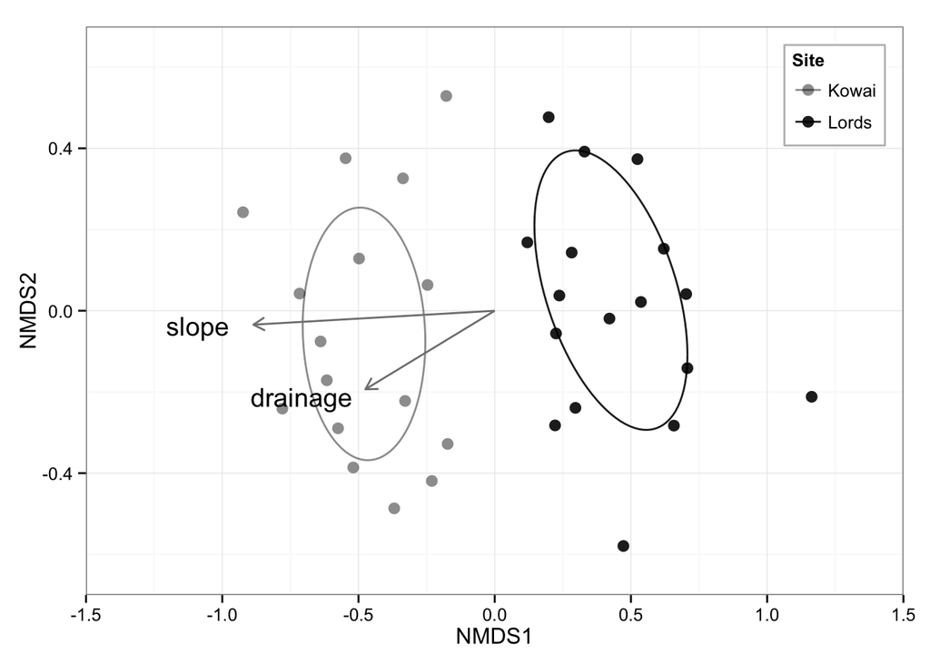

# Ordination methods

## Unconstrained: NMDS and the rest

```r
#data - from the vegan package:
#see ?mite for an explanation of what it is
data(mite)
head(mite[, 1:11], 3) #shows us first 3 lines of first 11 columns
```

```
##   Brachy PHTH HPAV RARD SSTR Protopl MEGR MPRO TVIE HMIN HMIN2
## 1     17    5    5    3    2       1    4    2    2    1     4
## 2      2    7   16    0    6       0    4    2    0    0     1
## 3      4    3    1    1    2       0    3    0    0    0     6
```

```r
data(mite.env)
head(mite.env, 3) #first three lines
```

```
##   SubsDens WatrCont Substrate Shrub    Topo
## 1    39.18    350.1   Sphagn1   Few Hummock
## 2    54.99    434.8    Litter   Few Hummock
## 3    46.07    371.7 Interface   Few Hummock
```

We might also want to do a quick visualisation of the data. Here we leave out Substrate because it’s a bit slow.

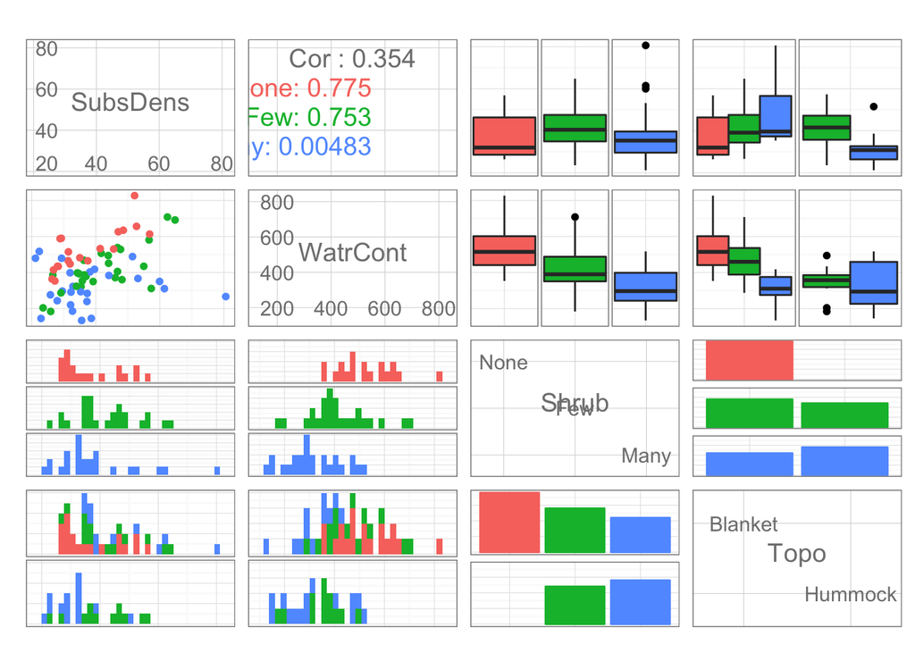

```r
ggpairs(mite.env[c(1:2,4:5)], colour = "Shrub") # yes the colours are atrocious.
```

```r
# alternatively, use the base version - faster - we can include Substrate, but less user  friendlly
pairs(mite.env)
```

[output not shown]

### NMDS

```r
set.seed(505) #set seed for reproducibility.
meta.nmds.mite <- metaMDS(mite) #no transformation of species data is made here
# prior to bray curtis dissimilarities being calculated.
#(Bray Curtis is the default in R).
meta.nmds.mite #prints very basic dsecription
```

[output not shown]

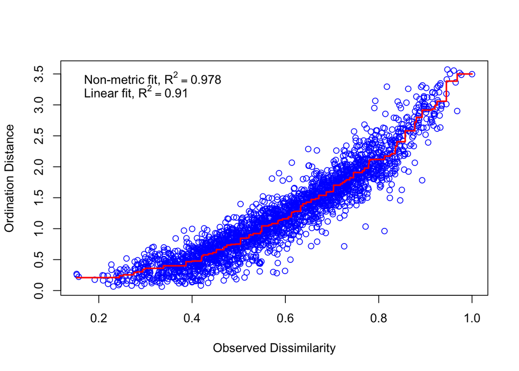

```r
stressplot(meta.nmds.mite) # To gain the stress plot for stress values for your NMDS
```

Once we’ve run the NMDS, we can plot the sites and their species in a plot. Here we’ve coloured them by topo type out of interest.

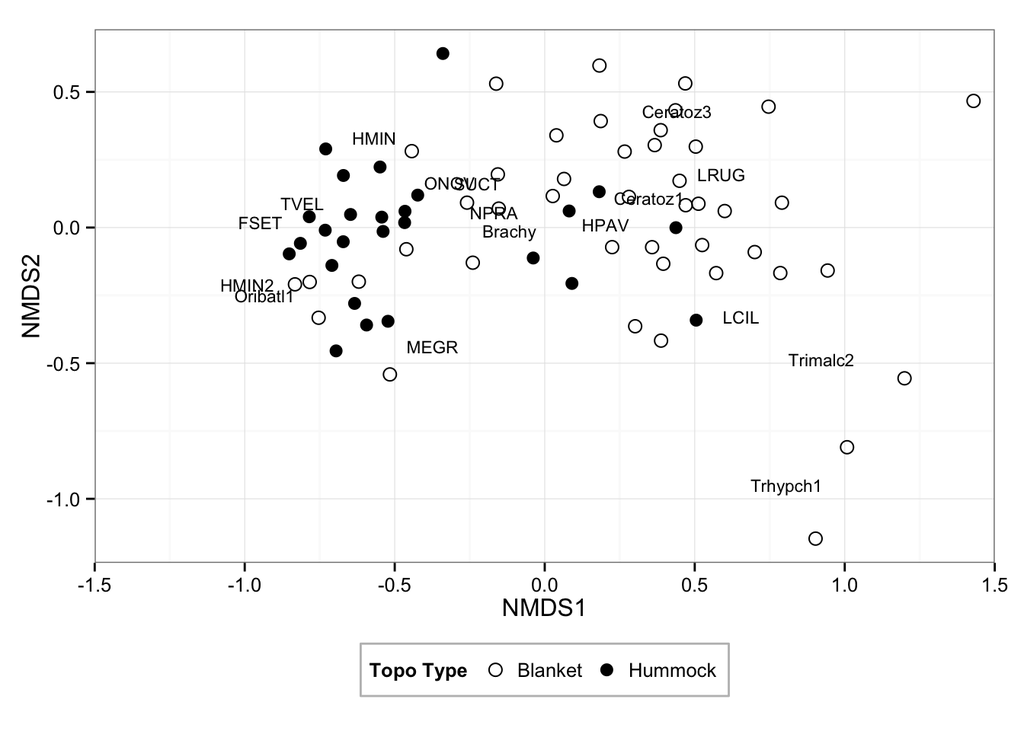